# STA207 Hw5 - Eric Kalosa-Kenyon

```r
library("gplots")           # pretty plotting
library("plyr")             # data.frame manipulation
library("gdata")            # reads .xlsx
library("additivityTests")  # interaction plots
library("multcomp")         # multiple comparison tests
```

# 26.4

## 26.4.a and 24.4.b

First, we fit $Y_{ijk}=\mu+\alpha_i+\beta_{j(i)}+\epsilon_{ijk}$.

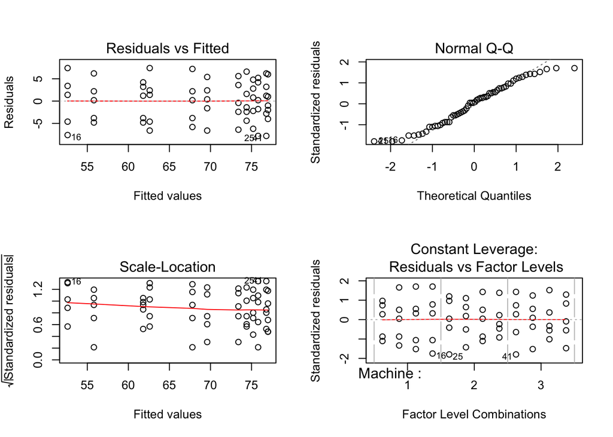

```r
# Load data
df1 = read.xls("PR26.4.xlsx", sheet = 1, header = TRUE)
df1$Machine = as.factor(df1$Machine)
df1$Operator = as.factor(df1$Operator)
df1$Day = as.factor(df1$Day)

# Fit and plot model
fit1 = with(df1, lm(Cases ~ Machine + Operator %in% Machine))
par(mfrow=c(2,2))
plot(fit1)
```

# 26.5

## 26.5.a

The opperator effects can be distinguished from shift effects if we ignore machine effects because we could employ the model $Y_{ij}=\mu+\alpha_i+\beta_j+\epsilon_{ij}$ where $n_{ij}=1$ for all $i,j$.

## 26.5.b

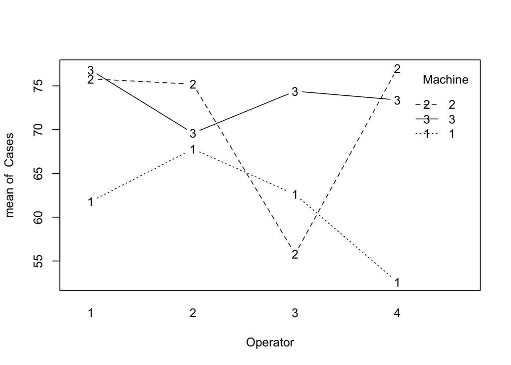

```r
with(df1, interaction.plot(Operator, Machine, Cases, type="b"))
```

It appears that Operators $1,4$ and $2,3$ are worse than the others and that Machine $1$ is worse than the others.

## 26.5.c

```r
aov1 = anova(fit1)
aov1
```

```
## Analysis of Variance Table
##
## Response: Cases
##                  Df Sum Sq Mean Sq F value    Pr(>F)
## Machine           2 1695.6  847.82  35.924 2.901e-10 ***
## Machine:Operator  9 2272.3  252.48  10.698 6.994e-09 ***
## Residuals        48 1132.8   23.60
## ---
## Signif. codes:  0 '***' 0.001 '**' 0.01 '*' 0.05 '.' 0.1 ' ' 1
```

## 26.5.d

The alternative hypothesis is that there is a difference between at least some machines. The decision rule is that if the emperical F statistic is larger than the theoretical F statistic at the prespecified significance level then we reject the null hypothesis that there is no such difference.

The p-value for machine effects in the nested model is $2.9011825\times 10^{-10}$ which is much smaller than $\alpha=0.01$ so we reject the null hypothesis that all machines are the same.

## 26.5.e

The alternative hypothesis is that there is a difference between at least some operators. The decision rule is that if the emperical F statistic is larger than the theoretical F statistic at the prespecified significance level then we reject the null hypothesis that there is no such difference.

## 26.5.f

To test each pair of machine effects, we use a Tukey multiple comparison correction factor on the standard error to generate the confidence intervals. If a Tukey confidence interval for a given point estimate overlaps another point estimate, we fail to reject the null hypothesis that the two machine effects are the same.

```r
summary(glht(fit1, linfct=mcp(Machine="Tukey")))
```

```
##
##   Simultaneous Tests for General Linear Hypotheses
##
## Multiple Comparisons of Means: Tukey Contrasts
##
##
## Fit: lm(formula = Cases ~ Machine + Operator %in% Machine)
##
## Linear Hypotheses:
##            Estimate Std. Error t value Pr(>|t|)
## 2 - 1 == 0   14.000      3.072   4.557 0.000111 ***
## 3 - 1 == 0   15.000      3.072   4.882  < 1e-04 ***
## 3 - 2 == 0    1.000      3.072   0.325 0.943355
## ---
## Signif. codes:  0 '***' 0.001 '**' 0.01 '*' 0.05 '.' 0.1 ' ' 1
## (Adjusted p values reported -- single-step method)
```

We see that indeed, as suspected in part b, machine $1$ is different from the other two machines which are themselves similar to each other.

## 26.5.g

To test for operator effects within each machine, we fit three models (one for each machine) and perform the Tukey corrected pairwise tests for each.

```r
fit11 = with(df1[df1$Machine == 1,], lm(Cases ~ Operator))
fit12 = with(df1[df1$Machine == 2,], lm(Cases ~ Operator))
fit13 = with(df1[df1$Machine == 3,], lm(Cases ~ Operator))
summary(glht(fit11, linfct=mcp(Operator="Tukey")))
```

```
##
##   Simultaneous Tests for General Linear Hypotheses
##
## Multiple Comparisons of Means: Tukey Contrasts
##
##
## Fit: lm(formula = Cases ~ Operator)
##
## Linear Hypotheses:
##            Estimate Std. Error t value Pr(>|t|)
## 2 - 1 == 0    6.000      3.339   1.797  0.31070
## 3 - 1 == 0    0.800      3.339   0.240  0.99497
## 4 - 1 == 0   -9.200      3.339  -2.755  0.06123 .
## 3 - 2 == 0   -5.200      3.339  -1.557  0.42890
## 4 - 2 == 0  -15.200      3.339  -4.552  0.00193 **
## 4 - 3 == 0  -10.000      3.339  -2.995  0.03833 *
## ---
## Signif. codes:  0 '***' 0.001 '**' 0.01 '*' 0.05 '.' 0.1 ' ' 1
## (Adjusted p values reported -- single-step method)
```

```r
summary(glht(fit12, linfct=mcp(Operator="Tukey")))
```

```
##
##   Simultaneous Tests for General Linear Hypotheses
##
## Multiple Comparisons of Means: Tukey Contrasts
##
##
## Fit: lm(formula = Cases ~ Operator)
##
## Linear Hypotheses:
##            Estimate Std. Error t value Pr(>|t|)
## 2 - 1 == 0   -0.600      2.839  -0.211    0.997
## 3 - 1 == 0  -20.000      2.839  -7.045   <1e-04 ***
## 4 - 1 == 0    1.200      2.839   0.423    0.974
## 3 - 2 == 0  -19.400      2.839  -6.833   <1e-04 ***
## 4 - 2 == 0    1.800      2.839   0.634    0.919
## 4 - 3 == 0   21.200      2.839   7.467   <1e-04 ***
## ---
## Signif. codes:  0 '***' 0.001 '**' 0.01 '*' 0.05 '.' 0.1 ' ' 1
## (Adjusted p values reported -- single-step method)
```

```r
summary(glht(fit13, linfct=mcp(Operator="Tukey")))
```

```
##
##   Simultaneous Tests for General Linear Hypotheses
##
## Multiple Comparisons of Means: Tukey Contrasts
##
##
## Fit: lm(formula = Cases ~ Operator)
##
## Linear Hypotheses:
##            Estimate Std. Error t value Pr(>|t|)
## 2 - 1 == 0   -7.200      3.018  -2.385    0.120
## 3 - 1 == 0   -2.400      3.018  -0.795    0.856
## 4 - 1 == 0   -3.400      3.018  -1.126    0.679
## 3 - 2 == 0    4.800      3.018   1.590    0.411
## 4 - 2 == 0    3.800      3.018   1.259    0.600
## 4 - 3 == 0   -1.000      3.018  -0.331    0.987
## (Adjusted p values reported -- single-step method)
```

In short, the differences expected in part b hold under formal statistical tests. In machine $1$, operator $4$ appears different from the rest - it is certianly different from operator $2$ at the $\alpha=0.01$ significance level. In machine $2$, operator $3$ is clearly worse than the others.

# 26.6

## 26.6.a

```r
summary(glht(fit1, linfct=mcp(Machine="Tukey")))
```

```
##
##   Simultaneous Tests for General Linear Hypotheses
##
## Multiple Comparisons of Means: Tukey Contrasts
##
##
## Fit: lm(formula = Cases ~ Machine + Operator %in% Machine)
##
## Linear Hypotheses:
##            Estimate Std. Error t value Pr(>|t|)
## 2 - 1 == 0   14.000      3.072   4.557 0.000104 ***
## 3 - 1 == 0   15.000      3.072   4.882  < 1e-04 ***
## 3 - 2 == 0    1.000      3.072   0.325 0.943349
## ---
## Signif. codes:  0 '***' 0.001 '**' 0.01 '*' 0.05 '.' 0.1 ' ' 1
## (Adjusted p values reported -- single-step method)
```

We see that machine $1$ is clearly different from the others at the $\alpha=0.05$ significance level.

## 26.6.b

```r
summary(glht(fit11, linfct=mcp(Operator="Tukey"), test=adjusted("bonferroni")))
```

```
##
##   Simultaneous Tests for General Linear Hypotheses
##
## Multiple Comparisons of Means: Tukey Contrasts
##
##
## Fit: lm(formula = Cases ~ Operator)
##
## Linear Hypotheses:
##            Estimate Std. Error t value Pr(>|t|)
## 2 - 1 == 0    6.000      3.339   1.797  0.31041
## 3 - 1 == 0    0.800      3.339   0.240  0.99496
## 4 - 1 == 0   -9.200      3.339  -2.755  0.06116 .
## 3 - 2 == 0   -5.200      3.339  -1.557  0.42869
## 4 - 2 == 0  -15.200      3.339  -4.552  0.00173 **
## 4 - 3 == 0  -10.000      3.339  -2.995  0.03865 *
## ---
## Signif. codes:  0 '***' 0.001 '**' 0.01 '*' 0.05 '.' 0.1 ' ' 1
## (Adjusted p values reported -- single-step method)
```

In machine $1$, we find that operator $4$ is different from operators $2$ and $3$ at the $\alpha=0.05$ significance level and the difference between operator $1$ and operator $4$ just misses the aforementioned significance level.

## 26.6.c

```r
m11 = with(df1, mean(Cases[Machine == 1 & Operator == 1]))
m12 = with(df1, mean(Cases[Machine == 1 & Operator == 2]))
m13 = with(df1, mean(Cases[Machine == 1 & Operator == 3]))
m14 = with(df1, mean(Cases[Machine == 1 & Operator == 4]))
L1 = (m11+m12+m13)/3-m14
n1 = length(unique(df1$Day))
b1 = length(unique(df1$Operator))
a1 = length(unique(df1$Machine))
df.mse1 = a1*b1*(n1-1)
mse1 = sum(fit1$residuals^2) / df.mse1
alp1 = .01
s1 = sqrt(1/(n1*b1)*sum(c(1/3,1/3,1/3,-1)^2)*mse1)
ci1 = s1*qt(1-alp1/2, a1-1)
```

The $\alpha=0.01$ confidence interval for $L=\frac{\mu_{11}+\mu_{12}+\mu_{13}}{3}-\mu_{14}$ is $11.4666667\pm12.4489874$. This suggests that we can’t reject the null hypothesis that the undertrained operator $4$ is less productive than his peers.

# 26.19

## 26.19.a and 26.19.b

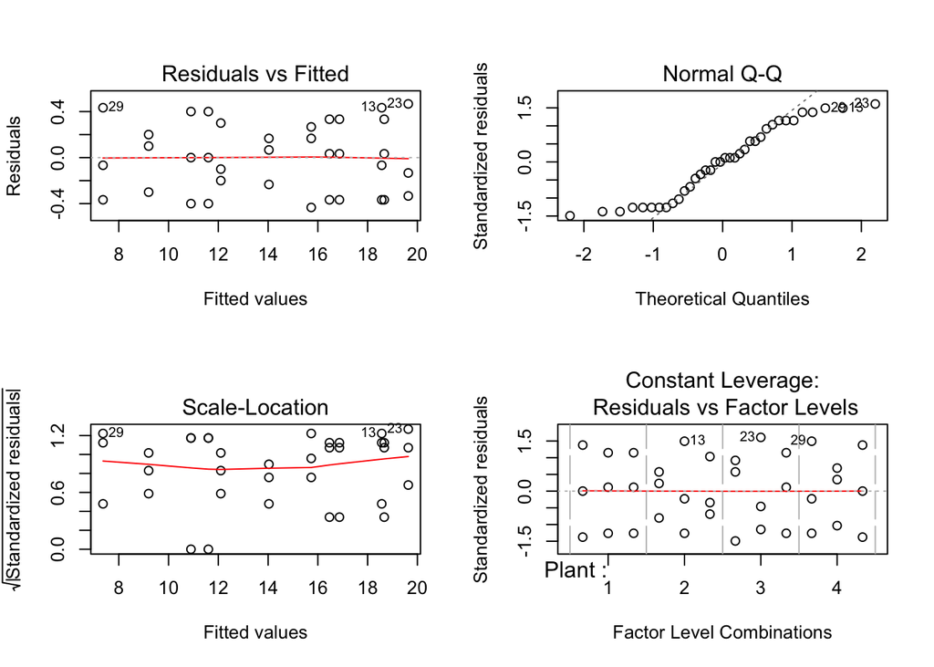

```r
df2 = read.xls("PR26.19.xlsx", sheet = 1, header = TRUE)
df2$Plant = as.factor(df2$Plant)
df2$Leaf = as.factor(df2$Leaf)
df2$Determination = as.factor(df2$Determination)

# Fit and plot model
fit2 = with(df2, lm(Acid ~ Plant + Leaf %in% Plant))
par(mfrow=c(2,2))
plot(fit2)
```

# 26.20

## 26.20.a

```r
aov2 = anova(fit2)
aov2
```

```
## Analysis of Variance Table
##
## Response: Acid
##            Df Sum Sq Mean Sq F value    Pr(>F)
## Plant       3 343.18 114.393  905.09 < 2.2e-16 ***
## Plant:Leaf  8 187.45  23.432  185.39 < 2.2e-16 ***
## Residuals  24   3.03   0.126
## ---
## Signif. codes:  0 '***' 0.001 '**' 0.01 '*' 0.05 '.' 0.1 ' ' 1
```

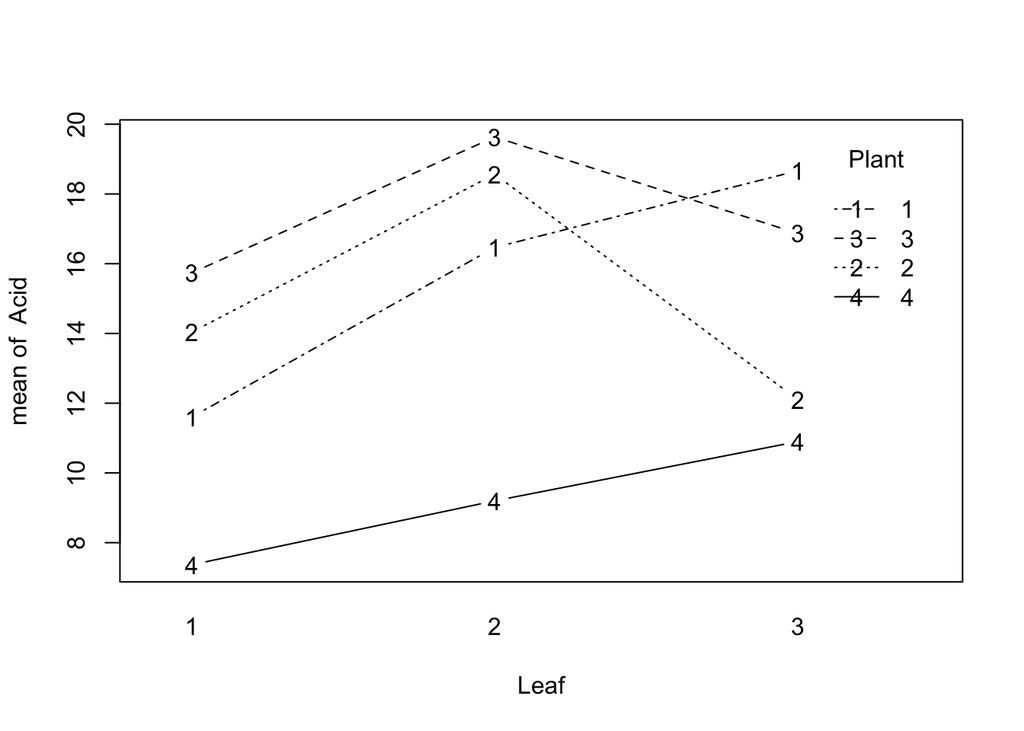

```r
with(df2, interaction.plot(Leaf, Plant, Acid, type="b"))
```

## 26.20.b and 26.20.c

The p-values for the F tests in the anova table are much smaller than $\alpha=0.05$ so we reject both the null hypothesis that there are no main effects and the null hypothesis that there are no nested effects using the same decision theoretic framework as in problem 26.5.

## 26.20.d

```r
alp = 0.05
m = mean(df2$Acid)
a = length(unique(df2$Plant))
b = length(unique(df2$Leaf))
n = length(unique(df2$Determination))
df = a*b*(n-1)
sse = sum(fit2$residuals^2)
mse = sse/df
s = sqrt(mse/(n*a*b))
ci = s*qt(1-alp/2, a-1)
```

The mean acid level in all plants is $14.2611111\pm0.1885664$.

## 26.20.e

```r
cs = fit2$coefficient
ah = c(cs[2], cs[3], cs[4], -sum(cs[2:4]))
bh = c(cs[5], cs[9], -(cs[5]+cs[9]),
    cs[6], cs[10], -(cs[6]+cs[10]),
    cs[7], cs[11], -(cs[7]+cs[11]),
    cs[8], cs[12], -(cs[8]+cs[12]))
ssa = n*b*sum(ah^2)
ssba = n*sum(bh^2)
dfa = a-1
dfba = a*(b-1)
msa = ssa/dfa
msba = ssba/dfba
s2a = (msa-msba)/(n*b)
s2 = mse
s2ba = (msba-mse)/n
```

# 27.6

## 27.6.a and 27.6.b

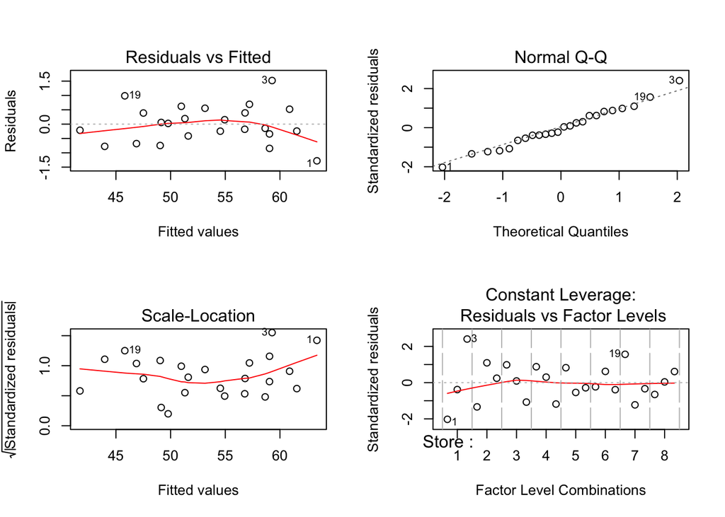

```r
df3 = read.xls("PR27.6.xlsx", sheet = 1, header = TRUE)
df3$Store = as.factor(df3$Store)
df3$Price = as.factor(df3$Price)
fit3 = with(df3, lm(Sales ~ Store + Price))
par(mfrow=c(2,2))
plot(fit3)
```

The residuals are mostly homoskedastic and they definitely fit the normality assumption. The residuals in stores $1$ and $7$ seem slightly high, but there are many stores so this could be a result of stochasticity rather than signal.

## 27.6.c

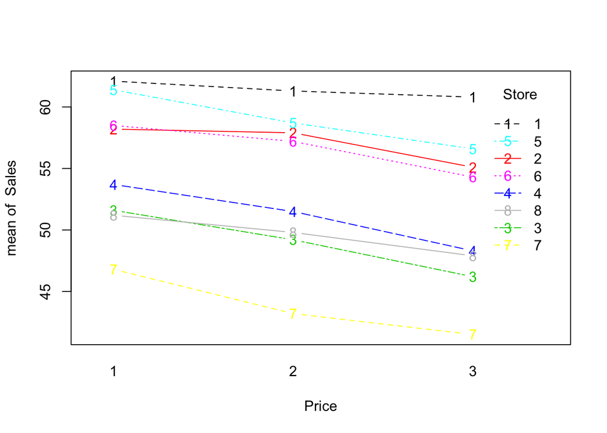

```r
with(df3, interaction.plot(Price, Store, Sales, col=1:8, type="b"))
```

There appears to be a strong store effect and there might be a small price effect. The assumption of no interactions between price and store appears appropriate.

## 27.6.d

```r
a = length(unique(df3$Store))
b = length(unique(df3$Price))
cs = fit3$coefficients
ah = c(cs[2:8], -sum(cs[2:8]))
bh = c(cs[9:10], -sum(cs[9:10]))

sse = sum(fit3$residuals^2)
ssa = b*sum(ah^2)
ssb = a*sum(bh^2)

dfe = (a-1)*(b-1)
dfa = a-1
dfb = b-1

mse = sse/dfe
msa = ssa/dfa
msb = ssb/dfb

M = matrix(df3$Sales, nrow=3, ncol=8)
colnames(M) = 1:8
rownames(M) = 1:3
tukey.test(M, alpha=0.01)
```

```
##
## Tukey test on 1% alpha-level:
##
## Test statistic: 5.765
## Critival value: 9.074
## The additivity hypothesis cannot be rejected.
```

The test statistic is lower than the critical value so we fail to reject the null hypothesis that $\hat{D}=0$ i.e. our model without the Tukey interactions is appropriate.

# 27.7

## 27.7.a

```r
aov3 = anova(fit3)
aov3
```

```
## Analysis of Variance Table
##
## Response: Sales
##           Df Sum Sq Mean Sq F value    Pr(>F)
## Store      7 745.19 106.455 155.693 3.473e-12 ***
## Price      2  67.48  33.740  49.346 4.567e-07 ***
## Residuals 14   9.57   0.684
## ---
## Signif. codes:  0 '***' 0.001 '**' 0.01 '*' 0.05 '.' 0.1 ' ' 1
```

## 27.7.b

```r
summary(glht(fit3, linfct=mcp(Price="Tukey")))
```

```
##
##   Simultaneous Tests for General Linear Hypotheses
##
## Multiple Comparisons of Means: Tukey Contrasts
##
##
## Fit: lm(formula = Sales ~ Store + Price)
##
## Linear Hypotheses:
##            Estimate Std. Error t value Pr(>|t|)
## 2 - 1 == 0  -1.8375     0.4134  -4.444  0.00154 **
## 3 - 1 == 0  -4.1000     0.4134  -9.917  < 0.001 ***
## 3 - 2 == 0  -2.2625     0.4134  -5.472  < 0.001 ***
## ---
## Signif. codes:  0 '***' 0.001 '**' 0.01 '*' 0.05 '.' 0.1 ' ' 1
## (Adjusted p values reported -- single-step method)
```

The differences in sales between price levels are all significant at the $\alpha=0.05$ significance level with exact p-values listed above.